# Assignment 1: Tuning a Neural Network for IMDB Review Classification

Advanced Machine Learning (64061) | Code, Output and Graphs

Shujath Ali Ansari Mohammed

September 27, 2026

# 1 Objective

The class example classifies IMDB movie reviews as positive or negative with a small fully-connected network (two hidden `Dense(16, relu)` layers, a sigmoid output, binary cross-entropy loss and RMSprop). In this assignment I change that network **one design choice at a time** to see how each choice affects validation and test accuracy, and then combine what I learned into a final model.

Questions addressed:

1. Does using **one or three hidden layers** instead of two help?
2. Do **more or fewer hidden units** (8, 16, 32, 64, 128) help?
3. What happens with **mse loss** instead of binary cross-entropy?
4. What happens with **tanh activation** instead of relu?
5. Can **regularization** from class (L2 weight decay, dropout) reduce overfitting and raise validation accuracy?

# 2 Setup

```r
library(keras3)      # Keras 3 for R (TensorFlow backend)
library(dplyr)
library(tidyr)
library(ggplot2)
library(knitr)

np       <- reticulate::import("numpy", convert = FALSE)
builtins <- reticulate::import_builtins()

SEEDS     <- c(123, 456, 789, 1011, 2024)[seq_len(params$n_seeds)]
EPOCHS    <- params$epochs
BATCH     <- 512
NUM_WORDS <- 10000

dir.create("results", showWarnings = FALSE)
RESULTS_FILE <- file.path("results", "experiment_results.rds")
```

# 3 Data

## 3.1 Load IMDB

Keras provides 50,000 reviews, already split into 25,000 training and 25,000 test reviews. Each review is a list of word IDs; only the 10,000 most frequent words are kept.

```r
imdb <- dataset_imdb(num_words = NUM_WORDS)
c(c(train_data, train_labels), c(test_data, test_labels)) %<-% imdb

cat("Training reviews:", length(train_data), "\n")
```

```
## Training reviews: 25000
```

```r
cat("Test reviews:    ", length(test_data), "\n")
```

```
## Test reviews:     25000
```

```r
cat("Share positive (train / test):", mean(train_labels), "/", mean(test_labels), "\n")
```

```
## Share positive (train / test): 0.5 / 0.5
```

```r
str(train_data[[1]][1:15])   # first 15 word IDs of the first review
```

```
##  int [1:15] 1 14 22 16 43 530 973 1622 1385 65 ...
```

## 3.2 Describe the data

```r
review_len <- lengths(c(train_data, test_data))

# Decode the first training review into words (illustration only).
# Word IDs are offset by 3 (0 = padding, 1 = start, 2 = unknown word).
example_review <- tryCatch({
  word_index    <- dataset_imdb_word_index()
  reverse_index <- setNames(names(word_index), unlist(word_index))
  words <- sapply(train_data[[1]], function(i)
    if (i > 3) reverse_index[[as.character(i - 3)]] else "?")
  paste(head(words[-1], 45), collapse = " ")
}, error = function(e) NA_character_)

data_facts <- list(
  n_train_total = length(train_data),
  n_test        = length(test_data),
  n_val         = 10000,
  len_quartiles = quantile(review_len, c(0.25, 0.5, 0.75)),
  pos_train     = mean(train_labels[10001:length(train_labels)]),
  pos_val       = mean(train_labels[1:10000]),
  pos_test      = mean(test_labels),
  example_review = example_review,
  example_label  = ifelse(train_labels[1] == 1, "positive", "negative"))

summary(review_len)
```

```
##    Min. 1st Qu.  Median    Mean 3rd Qu.    Max.
##     7.0   129.0   176.0   234.8   285.0  2494.0
```

```r
example_review
```

```
## [1] "this film was just brilliant casting location scenery story direction everyone's really suited the part they played and you could just imagine being there robert ? is an amazing actor and now the same being director ? father came from the same scottish island as"
```

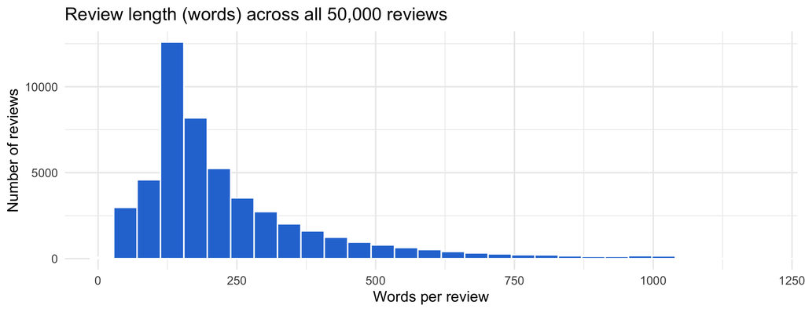

```r
ggplot(data.frame(words = review_len), aes(words)) +
  geom_histogram(bins = 60, fill = "#2a78d6", colour = "white") +
  coord_cartesian(xlim = c(0, 1200)) +
  labs(title = "Review length (words) across all 50,000 reviews",
       x = "Words per review", y = "Number of reviews") +
  theme_minimal(base_size = 12)
```

## 3.3 Multi-hot encoding

Each review becomes one row of 10,000 columns: 1 if the word appears in the review, 0 if not (word presence, not order). The matrix is built directly as a 32-bit NumPy array. That uses half the memory of an R matrix of doubles, and TensorFlow receives the data once instead of once per model.

```r
vectorize_sequences <- function(sequences, dimension = NUM_WORDS) {
  rows <- rep(seq_along(sequences), lengths(sequences)) - 1L   # review number (0-based)
  cols <- as.integer(unlist(sequences))                        # word ID of each word
  results <- np$zeros(c(length(sequences), as.integer(dimension)), dtype = "float32")
  results$`__setitem__`(reticulate::tuple(np$array(rows), np$array(cols)), 1)
  results
}

x_train_all <- vectorize_sequences(train_data)
x_test      <- vectorize_sequences(test_data)
y_train     <- as.numeric(train_labels)
y_test      <- as.numeric(test_labels)

data_facts$matrix_shape <- unlist(reticulate::py_to_r(x_train_all$shape))
data_facts$matrix_shape                                       # rows x columns
```

```
## [1] 25000 10000
```

```r
# Check: number of 1s in the first row = number of distinct words in review 1
c(ones_in_row_1 = reticulate::py_to_r(x_train_all$`__getitem__`(0L)$sum()),
  distinct_words = length(unique(train_data[[1]])))
```

```
##  ones_in_row_1 distinct_words
##            120            120
```

## 3.4 Validation split

As in class, the first 10,000 training reviews form the validation set; the remaining 15,000 are used for training. The test set is only used for final reporting, never for choosing a model.

```r
x_val           <- x_train_all$`__getitem__`(builtins$slice(0L, 10000L))
partial_x_train <- x_train_all$`__getitem__`(builtins$slice(10000L, 25000L))
y_val           <- y_train[1:10000]
partial_y_train <- y_train[10001:25000]

cat("Training:", length(partial_y_train), "| Validation:", length(y_val),
    "| Test:", length(y_test), "\n")
```

```
## Training: 15000 | Validation: 10000 | Test: 25000
```

# 4 Model functions

One function builds any variant of the network and one function trains and scores it, so every experiment runs through the same code and only the intended factor changes.

```r
# Build a network with n_layers hidden Dense layers, optional L2 penalty and dropout
build_model <- function(n_layers = 2, units = 16, activation = "relu",
                        l2 = 0, dropout = 0) {
  model <- keras_model_sequential(input_shape = NUM_WORDS)
  for (i in seq_len(n_layers)) {
    model |> layer_dense(
      units = units, activation = activation,
      kernel_regularizer = if (l2 > 0) keras3::regularizer_l2(l2 = l2) else NULL)
    if (dropout > 0) model |> layer_dropout(rate = dropout)
  }
  model |> layer_dense(units = 1, activation = "sigmoid")
  model
}

# Train one configuration with one seed and keep the weights from the best validation epoch
run_once <- function(cfg, seed) {
  set_random_seed(seed)                        # seeds R, Python, NumPy and TensorFlow
  model <- build_model(cfg$n_layers, cfg$units, cfg$activation, cfg$l2, cfg$dropout)
  model |> compile(optimizer = optimizer_rmsprop(), loss = cfg$loss,
                   metrics = list(metric_binary_accuracy(name = "accuracy")))

  ckpt <- tempfile(fileext = ".weights.h5")
  history <- model |> fit(
    partial_x_train, partial_y_train,
    epochs = EPOCHS, batch_size = BATCH,
    validation_data = list(x_val, y_val), verbose = 0,
    callbacks = list(callback_model_checkpoint(
      ckpt, monitor = "val_accuracy", mode = "max",
      save_best_only = TRUE, save_weights_only = TRUE)))

  load_model_weights(model, ckpt)              # restore the best-validation-epoch weights
  test_scores <- model |> evaluate(x_test, y_test, verbose = 0)
  unlink(ckpt)

  m <- history$metrics
  list(
    summary = tibble(config = cfg$config, seed = seed,
                     best_val_acc = max(m$val_accuracy),
                     best_epoch   = which.max(m$val_accuracy),
                     min_val_loss = min(m$val_loss),
                     test_acc     = test_scores$accuracy),
    curves = tibble(config = cfg$config, seed = seed, epoch = seq_along(m$loss),
                    loss = m$loss, val_loss = m$val_loss,
                    accuracy = m$accuracy, val_accuracy = m$val_accuracy))
}
```

# 5 Experiment design

Each configuration differs from the class baseline in **one** factor, except group F, which combines the most promising ideas. Controls held constant in every run: same data and split, RMSprop with the default learning rate, batch size 512, up to 20 epochs, 3 random seeds per configuration, and a checkpoint that keeps the epoch with the best validation accuracy (so models that overfit at different speeds are compared fairly).

```r
cfg <- function(config, group, n_layers = 2, units = 16, activation = "relu",
                loss = "binary_crossentropy", l2 = 0, dropout = 0)
  tibble(config, group, n_layers, units, activation, loss, l2, dropout)

configs <- bind_rows(
  cfg("Baseline (2x16 relu, BCE)", "Baseline"),
  cfg("1 hidden layer",            "A. Depth", n_layers = 1),
  cfg("3 hidden layers",           "A. Depth", n_layers = 3),
  cfg("8 units",                   "B. Width", units = 8),
  cfg("32 units",                  "B. Width", units = 32),
  cfg("64 units",                  "B. Width", units = 64),
  cfg("128 units",                 "B. Width", units = 128),
  cfg("MSE loss",                  "C. Loss", loss = "mse"),
  cfg("tanh activation",           "D. Activation", activation = "tanh"),
  cfg("L2 = 0.001",                "E. Regularization", l2 = 0.001),
  cfg("L2 = 0.0001",               "E. Regularization", l2 = 0.0001),
  cfg("Dropout 0.3",               "E. Regularization", dropout = 0.3),
  cfg("Dropout 0.5",               "E. Regularization", dropout = 0.5),
  cfg("L2 0.0001 + dropout 0.5",   "E. Regularization", l2 = 0.0001, dropout = 0.5),
  cfg("32 units + dropout 0.5",           "F. Combined", units = 32, dropout = 0.5),
  cfg("64 units + dropout 0.5",           "F. Combined", units = 64, dropout = 0.5),
  cfg("32 units + dropout 0.5 + L2 1e-4", "F. Combined", units = 32, dropout = 0.5, l2 = 0.0001),
  cfg("64 units + dropout 0.5 + L2 1e-4", "F. Combined", units = 64, dropout = 0.5, l2 = 0.0001)
)
kable(configs, caption = "All configurations")
```

All configurations

| config | group | n_layers | units | activation | loss | l2 | dropout |
| --- | --- | --- | --- | --- | --- | --- | --- |
| Baseline (2x16 relu, BCE) | Baseline | 2 | 16 | relu | binary_crossentropy | 0e+00 | 0.0 |
| 1 hidden layer | A. Depth | 1 | 16 | relu | binary_crossentropy | 0e+00 | 0.0 |
| 3 hidden layers | A. Depth | 3 | 16 | relu | binary_crossentropy | 0e+00 | 0.0 |
| 8 units | B. Width | 2 | 8 | relu | binary_crossentropy | 0e+00 | 0.0 |
| 32 units | B. Width | 2 | 32 | relu | binary_crossentropy | 0e+00 | 0.0 |
| 64 units | B. Width | 2 | 64 | relu | binary_crossentropy | 0e+00 | 0.0 |
| 128 units | B. Width | 2 | 128 | relu | binary_crossentropy | 0e+00 | 0.0 |
| MSE loss | C. Loss | 2 | 16 | relu | mse | 0e+00 | 0.0 |
| tanh activation | D. Activation | 2 | 16 | tanh | binary_crossentropy | 0e+00 | 0.0 |
| L2 = 0.001 | E. Regularization | 2 | 16 | relu | binary_crossentropy | 1e-03 | 0.0 |
| L2 = 0.0001 | E. Regularization | 2 | 16 | relu | binary_crossentropy | 1e-04 | 0.0 |
| Dropout 0.3 | E. Regularization | 2 | 16 | relu | binary_crossentropy | 0e+00 | 0.3 |
| Dropout 0.5 | E. Regularization | 2 | 16 | relu | binary_crossentropy | 0e+00 | 0.5 |
| L2 0.0001 + dropout 0.5 | E. Regularization | 2 | 16 | relu | binary_crossentropy | 1e-04 | 0.5 |
| 32 units + dropout 0.5 | F. Combined | 2 | 32 | relu | binary_crossentropy | 0e+00 | 0.5 |
| 64 units + dropout 0.5 | F. Combined | 2 | 64 | relu | binary_crossentropy | 0e+00 | 0.5 |
| 32 units + dropout 0.5 + L2 1e-4 | F. Combined | 2 | 32 | relu | binary_crossentropy | 1e-04 | 0.5 |
| 64 units + dropout 0.5 + L2 1e-4 | F. Combined | 2 | 64 | relu | binary_crossentropy | 1e-04 | 0.5 |

# 6 Train all models

18 configurations x 3 seeds. Progress is printed in the RStudio *Render* pane. If saved results with the same settings exist, they are reused. Set `rerun: true` in the header to retrain.

```r
saved_ok <- file.exists(RESULTS_FILE) && !params$rerun && {
  saved <- readRDS(RESULTS_FILE)
  identical(saved$seeds, SEEDS) && identical(saved$epochs, EPOCHS) &&
    all(configs$config %in% saved$runs$config)
}

if (saved_ok) {
  runs <- saved$runs; curves <- saved$curves
  cat("Loaded saved results from", RESULTS_FILE, "\n")
} else {
  out <- list()
  for (i in seq_len(nrow(configs))) {
    for (s in SEEDS) {
      message(sprintf("[%s] %s | seed %d", format(Sys.time(), "%H:%M:%S"),
                      configs$config[i], s))
      out[[length(out) + 1]] <- run_once(configs[i, ], s)
    }
  }
  runs   <- bind_rows(lapply(out, `[[`, "summary"))
  curves <- bind_rows(lapply(out, `[[`, "curves"))
}
```

```
## Loaded saved results from results/experiment_results.rds
```

# 7 Results

## 7.1 Summarise across seeds

Mean and standard deviation of best validation accuracy across seeds, and the change compared with the baseline in percentage points (pp).

```r
results <- runs |>
  filter(config %in% configs$config) |>
  group_by(config) |>
  summarise(val_acc = mean(best_val_acc), val_sd = sd(best_val_acc),
            test_acc = mean(test_acc), best_epoch = median(best_epoch),
            min_val_loss = mean(min_val_loss), .groups = "drop") |>
  mutate(val_sd = ifelse(is.na(val_sd), 0, val_sd)) |>
  inner_join(configs, by = "config")

base    <- filter(results, group == "Baseline")
results <- mutate(results, delta_vs_base = val_acc - base$val_acc)
base_name <- base$config

# Differences smaller than this are treated as run-to-run noise (at least 0.2 pp)
NOISE <- max(0.002, 2 * mean(results$val_sd))
cat(sprintf("Noise threshold: %.2f pp\n", 100 * NOISE))
```

```
## Noise threshold: 0.25 pp
```

```r
# Helpers for tables and plots
pct <- function(x) sprintf("%.2f%%", 100 * x)
pp  <- function(x) sprintf("%+.2f pp", 100 * x)

show_table <- function(df, caption) {
  df |>
    arrange(desc(val_acc)) |>
    transmute(Configuration = config,
              `Val acc (mean)` = pct(val_acc),
              `± SD` = sprintf("%.2f", 100 * val_sd),
              `Δ vs baseline` = pp(delta_vs_base),
              `Best epoch` = best_epoch,
              `Min val loss` = sprintf("%.3f", min_val_loss),
              `Test acc` = pct(test_acc)) |>
    kable(caption = caption, align = "lrrrrrr")
}

plot_curves <- function(cfg_names, metric = c("loss", "accuracy"), title = NULL) {
  metric <- match.arg(metric)
  curves |>
    filter(config %in% cfg_names) |>
    group_by(config, epoch) |>
    summarise(Training = mean(.data[[metric]]),
              Validation = mean(.data[[paste0("val_", metric)]]), .groups = "drop") |>
    pivot_longer(c(Training, Validation), names_to = "split", values_to = "value") |>
    mutate(config = factor(config, levels = cfg_names)) |>
    ggplot(aes(epoch, value, colour = split)) +
    geom_line(linewidth = 0.9) + geom_point(size = 1.4) +
    facet_wrap(~config) +
    scale_colour_manual(values = c(Training = "#2a78d6", Validation = "#F28CB1")) +
    labs(title = title, x = "Epoch", y = tools::toTitleCase(metric), colour = NULL) +
    theme_minimal(base_size = 12) + theme(legend.position = "top")
}
```

## 7.2 Baseline: the model from class

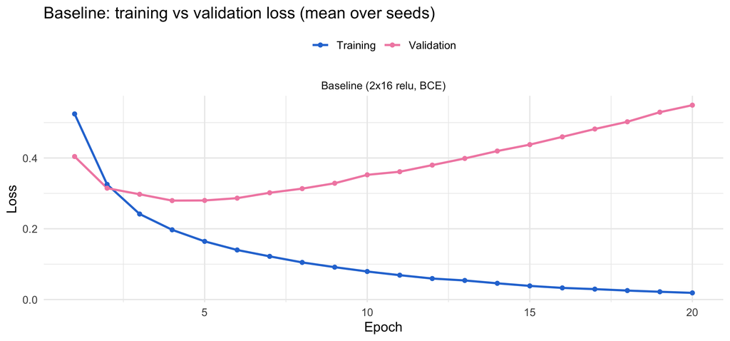

```r
plot_curves(base_name, "loss", "Baseline: training vs validation loss (mean over seeds)")
```

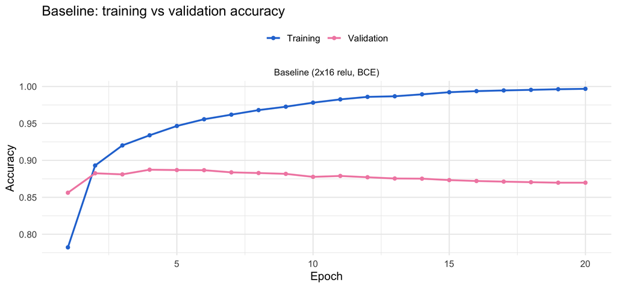

```r
plot_curves(base_name, "accuracy", "Baseline: training vs validation accuracy")
```

Training loss keeps falling for all 20 epochs while validation loss bottoms out after about 4 epochs and then climbs: the classic sign of overfitting. Baseline best validation accuracy: **88.82%**.

## 7.3 A. Number of hidden layers

```r
show_table(filter(results, group %in% c("Baseline", "A. Depth")),
           "Effect of depth (16 units per layer)")
```

Effect of depth (16 units per layer)

| Configuration | Val acc (mean) | ± SD | Δ vs baseline | Best epoch | Min val loss | Test acc |
| --- | --- | --- | --- | --- | --- | --- |
| 1 hidden layer | 88.91% | 0.13 | +0.10 pp | 4 | 0.278 | 88.31% |
| Baseline (2x16 relu, BCE) | 88.82% | 0.09 | +0.00 pp | 4 | 0.279 | 88.02% |
| 3 hidden layers | 88.81% | 0.15 | -0.01 pp | 5 | 0.280 | 88.12% |

## 7.4 B. Number of hidden units

```r
width <- filter(results, group %in% c("Baseline", "B. Width"))
show_table(width, "Effect of width (2 hidden layers)")
```

Effect of width (2 hidden layers)

| Configuration | Val acc (mean) | ± SD | Δ vs baseline | Best epoch | Min val loss | Test acc |
| --- | --- | --- | --- | --- | --- | --- |
| 32 units | 89.04% | 0.07 | +0.22 pp | 4 | 0.276 | 88.30% |
| 8 units | 88.96% | 0.08 | +0.14 pp | 5 | 0.278 | 88.21% |
| 64 units | 88.83% | 0.06 | +0.01 pp | 4 | 0.277 | 88.14% |
| Baseline (2x16 relu, BCE) | 88.82% | 0.09 | +0.00 pp | 4 | 0.279 | 88.02% |
| 128 units | 88.73% | 0.12 | -0.09 pp | 4 | 0.277 | 88.20% |

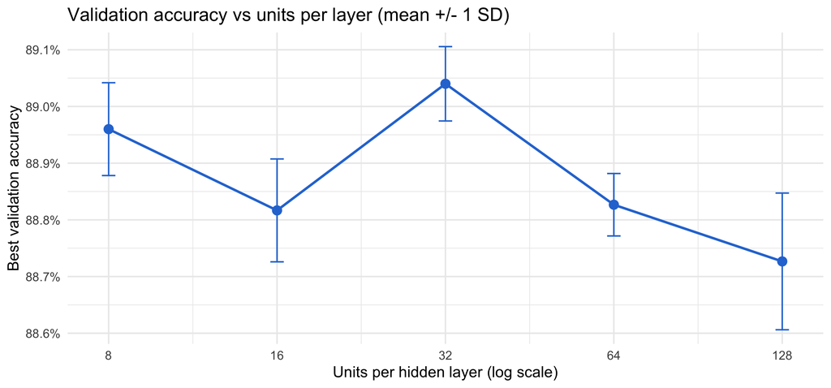

```r
width |>
  ggplot(aes(units, val_acc)) +
  geom_line(colour = "#2a78d6", linewidth = 0.9) +
  geom_errorbar(aes(ymin = val_acc - val_sd, ymax = val_acc + val_sd),
                width = 0.08, colour = "#2a78d6") +
  geom_point(size = 3, colour = "#2a78d6") +
  scale_x_continuous(trans = "log2", breaks = c(8, 16, 32, 64, 128)) +
  scale_y_continuous(labels = scales::percent_format(accuracy = 0.1)) +
  labs(title = "Validation accuracy vs units per layer (mean +/- 1 SD)",
       x = "Units per hidden layer (log scale)", y = "Best validation accuracy") +
  theme_minimal(base_size = 12)
```

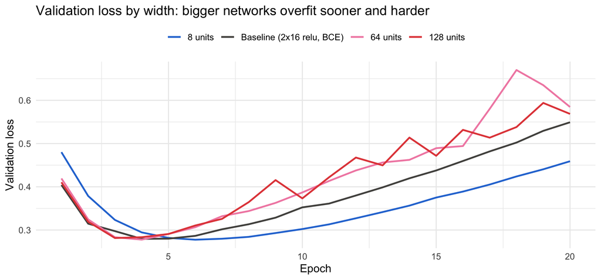

```r
width_names <- c("8 units", base_name, "64 units", "128 units")
curves |>
  filter(config %in% width_names) |>
  group_by(config, epoch) |> summarise(val_loss = mean(val_loss), .groups = "drop") |>
  mutate(config = factor(config, levels = width_names)) |>
  ggplot(aes(epoch, val_loss, colour = config)) + geom_line(linewidth = 0.9) +
  scale_colour_manual(values = c("#2a78d6", "#52514e", "#F28CB1", "#e34948")) +
  labs(title = "Validation loss by width: bigger networks overfit sooner and harder",
       x = "Epoch", y = "Validation loss", colour = NULL) +
  theme_minimal(base_size = 12) + theme(legend.position = "top")
```

## 7.5 C. Loss function: mse vs binary cross-entropy

```r
show_table(filter(results, group %in% c("Baseline", "C. Loss")),
           "Effect of the loss function")
```

Effect of the loss function

| Configuration | Val acc (mean) | ± SD | Δ vs baseline | Best epoch | Min val loss | Test acc |
| --- | --- | --- | --- | --- | --- | --- |
| Baseline (2x16 relu, BCE) | 88.82% | 0.09 | +0.00 pp | 4 | 0.279 | 88.02% |
| MSE loss | 88.73% | 0.12 | -0.08 pp | 5 | 0.083 | 88.19% |

Note: the “Min val loss” column is not comparable across these two rows, because mse and cross-entropy are on different scales.

## 7.6 D. Activation: tanh vs relu

```r
show_table(filter(results, group %in% c("Baseline", "D. Activation")),
           "Effect of the hidden-layer activation")
```

Effect of the hidden-layer activation

| Configuration | Val acc (mean) | ± SD | Δ vs baseline | Best epoch | Min val loss | Test acc |
| --- | --- | --- | --- | --- | --- | --- |
| Baseline (2x16 relu, BCE) | 88.82% | 0.09 | +0.00 pp | 4 | 0.279 | 88.02% |
| tanh activation | 88.80% | 0.21 | -0.02 pp | 4 | 0.276 | 88.07% |

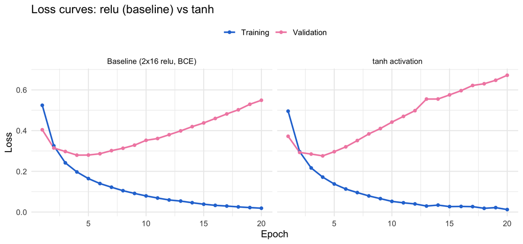

```r
plot_curves(c(base_name, "tanh activation"), "loss", "Loss curves: relu (baseline) vs tanh")
```

## 7.7 E. Regularization: L2 and dropout

```r
show_table(filter(results, group %in% c("Baseline", "E. Regularization")),
           "Effect of regularization (2 x 16 relu)")
```

Effect of regularization (2 x 16 relu)

| Configuration | Val acc (mean) | ± SD | Δ vs baseline | Best epoch | Min val loss | Test acc |
| --- | --- | --- | --- | --- | --- | --- |
| Dropout 0.3 | 88.93% | 0.11 | +0.11 pp | 5 | 0.279 | 88.31% |
| L2 0.0001 + dropout 0.5 | 88.89% | 0.02 | +0.07 pp | 7 | 0.290 | 88.37% |
| Dropout 0.5 | 88.83% | 0.08 | +0.02 pp | 7 | 0.281 | 88.31% |
| Baseline (2x16 relu, BCE) | 88.82% | 0.09 | +0.00 pp | 4 | 0.279 | 88.02% |
| L2 = 0.0001 | 88.80% | 0.10 | -0.02 pp | 3 | 0.287 | 88.23% |
| L2 = 0.001 | 88.73% | 0.07 | -0.09 pp | 5 | 0.330 | 88.19% |

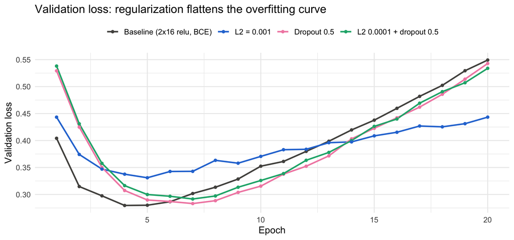

```r
reg_names <- c(base_name, "L2 = 0.001", "Dropout 0.5", "L2 0.0001 + dropout 0.5")
curves |>
  filter(config %in% reg_names) |>
  group_by(config, epoch) |> summarise(val_loss = mean(val_loss), .groups = "drop") |>
  mutate(config = factor(config, levels = reg_names)) |>
  ggplot(aes(epoch, val_loss, colour = config)) +
  geom_line(linewidth = 0.9) + geom_point(size = 1.3) +
  scale_colour_manual(values = c("#52514e", "#2a78d6", "#F28CB1", "#1baf7a")) +
  labs(title = "Validation loss: regularization flattens the overfitting curve",
       x = "Epoch", y = "Validation loss", colour = NULL) +
  theme_minimal(base_size = 12) + theme(legend.position = "top")
```

## 7.8 F. Combined candidates

```r
show_table(filter(results, group %in% c("Baseline", "F. Combined")),
           "Combined candidates (chosen on validation accuracy)")
```

Combined candidates (chosen on validation accuracy)

| Configuration | Val acc (mean) | ± SD | Δ vs baseline | Best epoch | Min val loss | Test acc |
| --- | --- | --- | --- | --- | --- | --- |
| 32 units + dropout 0.5 | 89.02% | 0.20 | +0.20 pp | 5 | 0.277 | 88.33% |
| 32 units + dropout 0.5 + L2 1e-4 | 88.91% | 0.14 | +0.09 pp | 5 | 0.288 | 88.37% |
| 64 units + dropout 0.5 | 88.86% | 0.24 | +0.04 pp | 4 | 0.280 | 88.16% |
| Baseline (2x16 relu, BCE) | 88.82% | 0.09 | +0.00 pp | 4 | 0.279 | 88.02% |
| 64 units + dropout 0.5 + L2 1e-4 | 88.81% | 0.22 | -0.01 pp | 4 | 0.300 | 88.05% |

# 8 Final model: retrain on all training data and test once

The final model is the configuration with the highest mean validation accuracy across the whole study (the test set is not used for this choice). It is retrained from scratch on all 25,000 training reviews for its best number of epochs, then evaluated once on the test set. The baseline gets the same treatment for comparison.

```r
final     <- results |> slice_max(val_acc, n = 1, with_ties = FALSE)
final_cfg <- filter(configs, config == final$config)
base_cfg  <- filter(configs, config == base_name)
cat("Selected final model:", final$config, "\n")
```

```
## Selected final model: 32 units
```

```r
cat(sprintf("Validation accuracy: %s vs baseline %s (%s)\n",
            pct(final$val_acc), pct(base$val_acc), pp(final$delta_vs_base)))
```

```
## Validation accuracy: 89.04% vs baseline 88.82% (+0.22 pp)
```

```r
train_full <- function(cfg, epochs, seed) {
  set_random_seed(seed)
  model <- build_model(cfg$n_layers, cfg$units, cfg$activation, cfg$l2, cfg$dropout)
  model |> compile(optimizer = optimizer_rmsprop(), loss = cfg$loss,
                   metrics = list(metric_binary_accuracy(name = "accuracy")))
  model |> fit(x_train_all, y_train, epochs = epochs, batch_size = BATCH, verbose = 0)
  model |> evaluate(x_test, y_test, verbose = 0)
}

if (saved_ok && !is.null(saved$final_full) &&
    identical(saved$final_full$final_config, final$config)) {
  final_full <- saved$final_full
} else {
  rows <- list()
  for (s in SEEDS) {
    fb <- train_full(base_cfg,  max(1, round(base$best_epoch)),  s)
    ff <- train_full(final_cfg, max(1, round(final$best_epoch)), s)
    rows[[length(rows) + 1]] <- tibble(seed = s, baseline = fb$accuracy, final = ff$accuracy)
  }
  final_full <- list(final_config = final$config, table = bind_rows(rows))
}

ft <- final_full$table
kable(ft, digits = 4, caption = "Test accuracy per seed after retraining on all 25,000 training reviews")
```

Test accuracy per seed after retraining on all 25,000 training reviews

| seed | baseline | final |
| --- | --- | --- |
| 123 | 0.8857 | 0.8789 |
| 456 | 0.8807 | 0.8840 |
| 789 | 0.8838 | 0.8851 |

```r
tibble(Model = c(paste0("Baseline (", round(base$best_epoch), " epochs)"),
                 paste0("Final: ", final$config, " (", round(final$best_epoch), " epochs)")),
       `Test accuracy (mean)` = pct(c(mean(ft$baseline), mean(ft$final))),
       `± SD` = sprintf("%.2f", 100 * c(sd(ft$baseline), sd(ft$final)))) |>
  kable(caption = "Test accuracy after retraining (mean over seeds)")
```

Test accuracy after retraining (mean over seeds)

| Model | Test accuracy (mean) | ± SD |
| --- | --- | --- |
| Baseline (4 epochs) | 88.34% | 0.25 |
| Final: 32 units (4 epochs) | 88.27% | 0.33 |

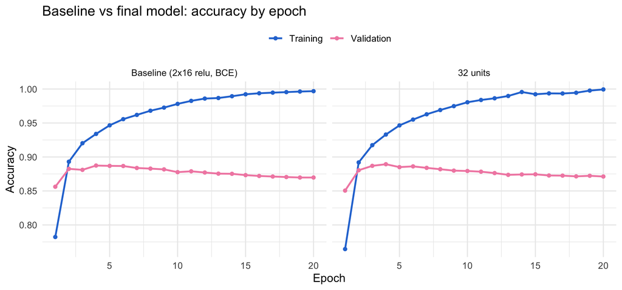

```r
plot_curves(c(base_name, final$config), "accuracy", "Baseline vs final model: accuracy by epoch")
```

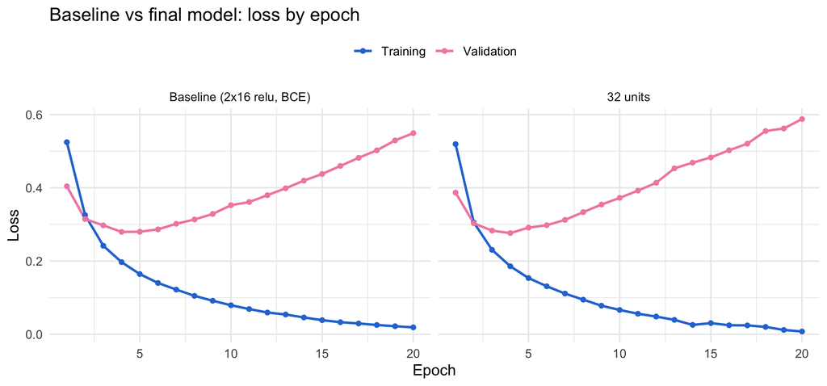

```r
plot_curves(c(base_name, final$config), "loss", "Baseline vs final model: loss by epoch")
```